# ggplot - last notes

session 6b

Eviatar Guttman

Last updated: 27-06-2021

```r
library(tidyverse); library(patchwork)
```

# 1 scales

## 1.1 intro

באופן פורמלי כל `scale` הוא פונקציה מתחום במרחב הנתונים לטווח במרחב האסטטי.  
כל רכיב אסטטי (aesthetic) בגרף מתאים ל-scale אחד ויחיד.  
כאשר אנו כותבים את הקוד הבא:

```r
ggplot(mpg, aes(displ, hwy)) +
  geom_point(aes(colour = class))
```

Ggplot מוסיפה את ה-scales הבאים:

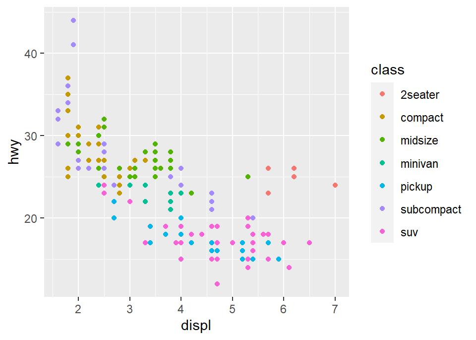

```r
ggplot(mpg, aes(displ, hwy)) +
  geom_point(aes(colour = class)) +
  scale_x_continuous() +
  scale_y_continuous() +
  scale_colour_discrete()
```

ggplot בוחרת את ה-scale לפי סוג ה-aesthetic ולפי סוג המשתנה.

אם רוצים לשנות את ערך ברירת המחדל, יש להוסיף את פונקציית ה-scale בעצמנו ולבחור ערכים.

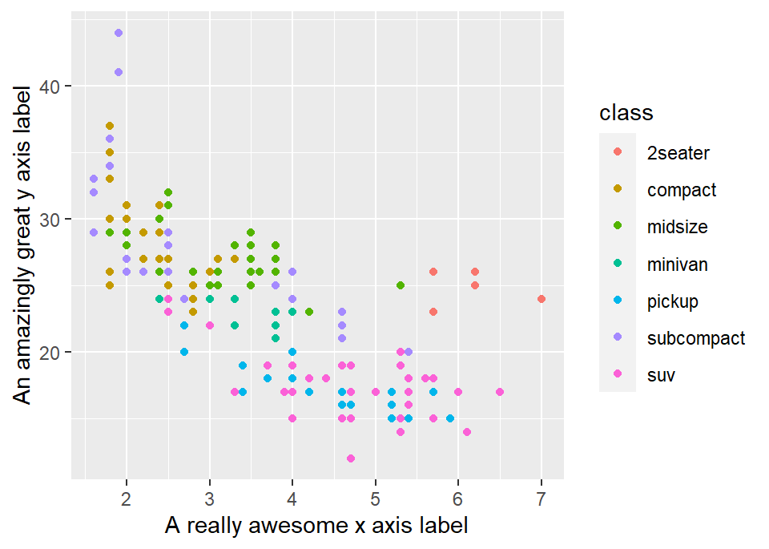

```r
ggplot(mpg, aes(displ, hwy)) +
  geom_point(aes(colour = class)) +
  scale_x_continuous(name = "A really awesome x axis label") +
  scale_y_continuous(name = "An amazingly great y axis label")
```

אם המשתמש מספק שני scales לאותו aesthetic, אז האחרון הוא שקובע.

דוגמא נוספת: נהפוך את ה-aesthetic של גודל הנקודה:

```r
df <- data.frame(x = runif(20), y = runif(20), z = sample(20))

head(df)
```

```
##           x          y  z
## 1 0.3189429 0.26269016  9
## 2 0.1196580 0.23922851  8
## 3 0.1162232 0.49872724 12
## 4 0.2724891 0.05375096 14
## 5 0.3147349 0.24500754 15
## 6 0.8203054 0.67968406 13
```

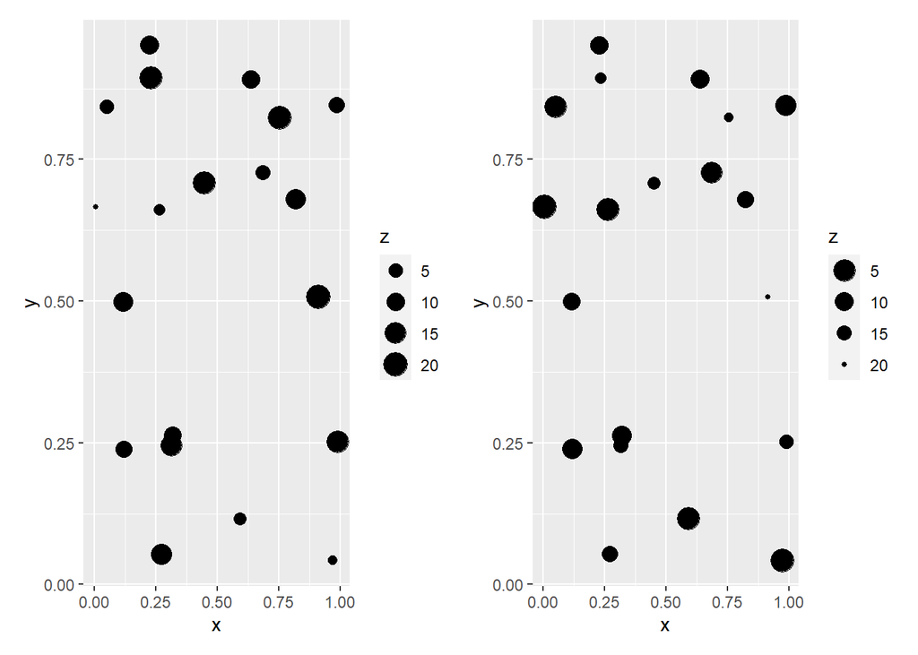

```r
base <- ggplot(df, aes(x, y, size = z)) + geom_point()

p1 <- base
p2 <- base + scale_size(trans = "reverse")

p1 + p2
```

ניתן לפרש את התרשים השמאלי כמשקל או גודל קבוצה. את התרשים הימני ניתן לפרש כמרחק.

המידע שהצופה מפענח מציר ה-x, y או ה-legend נקרא guide. ה-guide הוא תוצאה של פונקציה הפוכה, ההופכת בחזרה את המידע ויזואלי לנתונים.

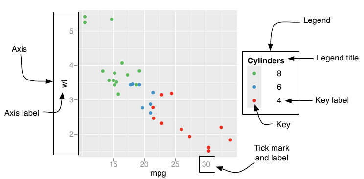

את ה-legend ניתן לשנות בכל מיני אופנים, הם יכולים להציג יותר מ-aesthetic אחד, הם יכולים להופיע במקומות שונים בגרף ויש יותר מאפיינים שניתן לשנות בהם.

### 1.1.1 exercise

מה יקרה אם נשדך משתנה בדיד ל-scale רציף? מה יקרה אם נשדך משתנה רציף ל-scale בדיד?

## 1.2 numeric

most common continuous position scales are default `scale_x_continuous()` and `scale_y_continuous()` functions. simplest case - map linearly from the data value to a location on the plot. non linear examples are: `scale_x_log10()`, `scale_x_reverse()`,

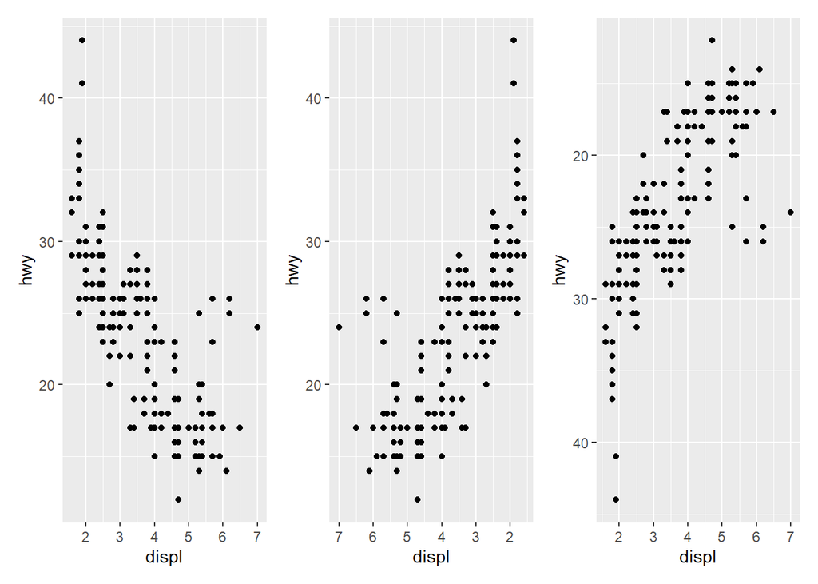

```r
p1 <- ggplot(mpg, aes(displ, hwy)) + geom_point()

p2 <- p1 + scale_x_reverse()
p3 <- p1 + scale_y_reverse()

p1 + p2 + p3
```

check the list of options in the the argument `trans` in `?scale_x_continuous()`

## 1.3 transformation

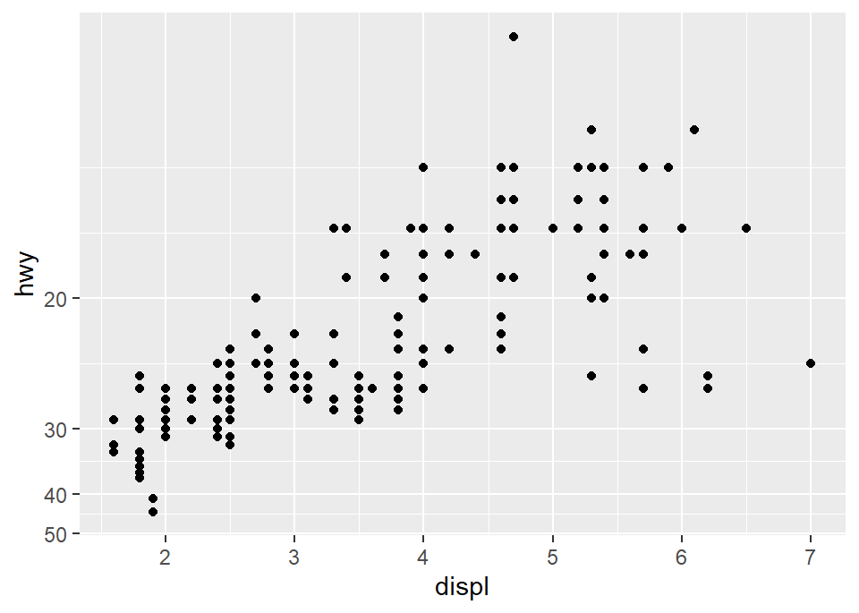

```r
ggplot(mpg, aes(displ, hwy)) +
  geom_point() +
  scale_y_continuous(trans = "reciprocal")
```

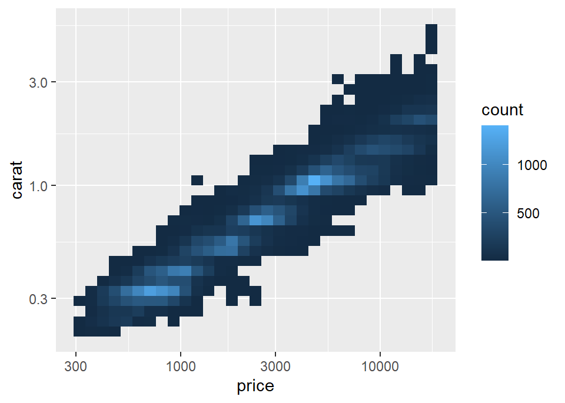

```r
# log transform x and y axes
ggplot(diamonds, aes(price, carat)) +
  geom_bin2d() +
  scale_x_continuous(trans = "log10") +
  scale_y_continuous(trans = "log10")
```

יש הבדל בין שינוי scale לבין טרנספורמציה למשתנה עצמו

Note that there is nothing preventing you from performing these transformations manually. For example, instead of using `scale_x_log10()` to transform the scale, you could transform the data instead and plot `log10(x)`. The appearance of the geom will be the same, but the tick labels will be different. Specifically, if you use a transformed scale, the axes will be labeled in the original data space; if you transform the data, the axes will be labeled in the transformed space.

Regardless of which method you use, the transformation occurs before any statistical summaries.

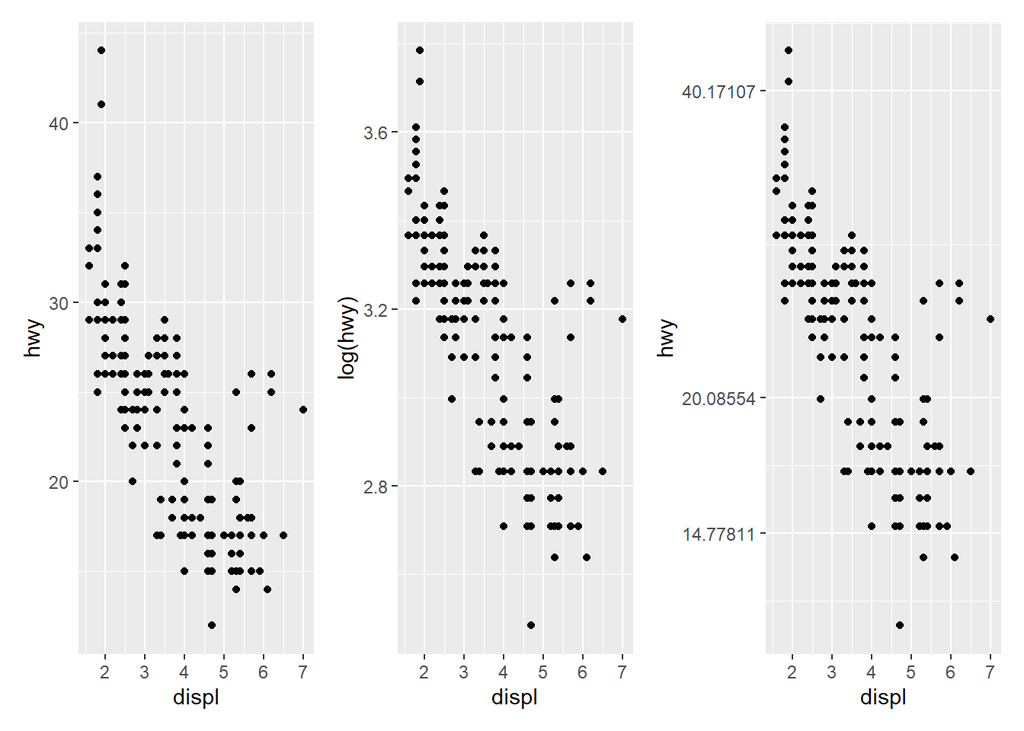

```r
p0 <- ggplot(mpg, aes(displ, hwy)) + geom_point()

p1 <- ggplot(mpg, aes(displ, log(hwy))) + geom_point()

p2 <- ggplot(mpg, aes(displ, hwy)) + geom_point() + scale_y_continuous(trans = "log")

p0 + p1 + p2
```

## 1.4 breaks

the breaks argument controls which values appear as tick marks on axes and as keys on legends.

```r
toy <- data.frame(
  const = 1,
  up = 1:4,
  txt = letters[1:4],
  big = (1:4)*1000,
  log = c(2, 5, 10, 2000)
)
toy
```

```
##   const up txt  big  log
## 1     1  1   a 1000    2
## 2     1  2   b 2000    5
## 3     1  3   c 3000   10
## 4     1  4   d 4000 2000
```

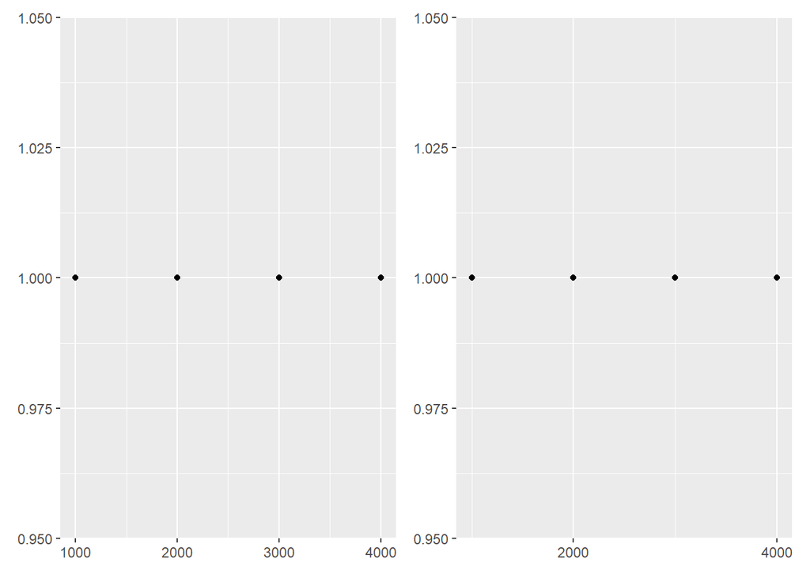

```r
axs <- ggplot(toy, aes(big, const)) +
  geom_point() +
  labs(x = NULL, y = NULL)

p1 <- axs
p2 <- axs + scale_x_continuous(breaks = c(2000, 4000))
p1 + p2
```

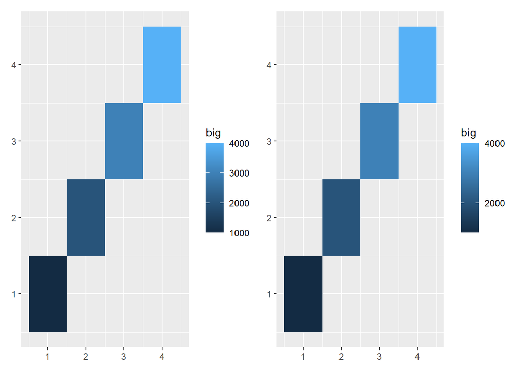

```r
leg <- ggplot(toy, aes(up, up, fill = big)) +
  geom_tile() +
  labs(x = NULL, y = NULL)

p1 <- leg
p2 <- leg + scale_fill_continuous(breaks = c(2000, 4000))

p1 + p2
```

there are functions to automate the breaks:

`scales::breaks_extended()` creates automatic breaks for numeric axes.  
`scales::breaks_log()` creates breaks appropriate for log axes.  
`scales::breaks_pretty()` creates “pretty” breaks for date/times.  
`scales::breaks_width()` creates equally spaced breaks.

```r
toy <- data.frame(
  const = 1,
  up = 1:4,
  txt = letters[1:4],
  big = (1:4)*1000,
  log = c(2, 5, 10, 2000)
)
toy
```

```
##   const up txt  big  log
## 1     1  1   a 1000    2
## 2     1  2   b 2000    5
## 3     1  3   c 3000   10
## 4     1  4   d 4000 2000
```

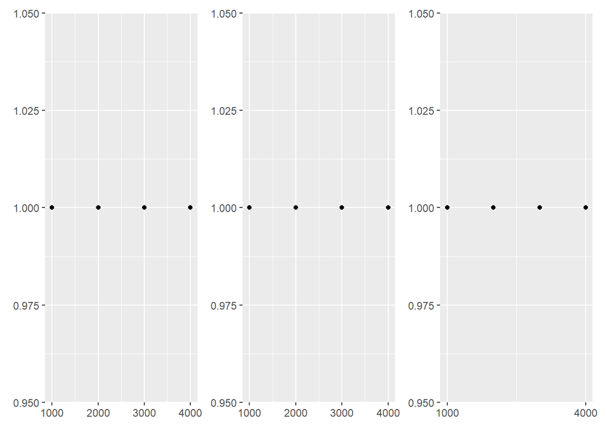

```r
axs <- ggplot(toy, aes(big, const)) +
  geom_point() +
  labs(x = NULL, y = NULL)

p1 <- axs

p2 <- axs + scale_x_continuous(breaks = scales::breaks_extended())

p3 <- axs + scale_x_continuous(breaks = scales::breaks_extended(n = 2))

p1 + p2 + p3
```

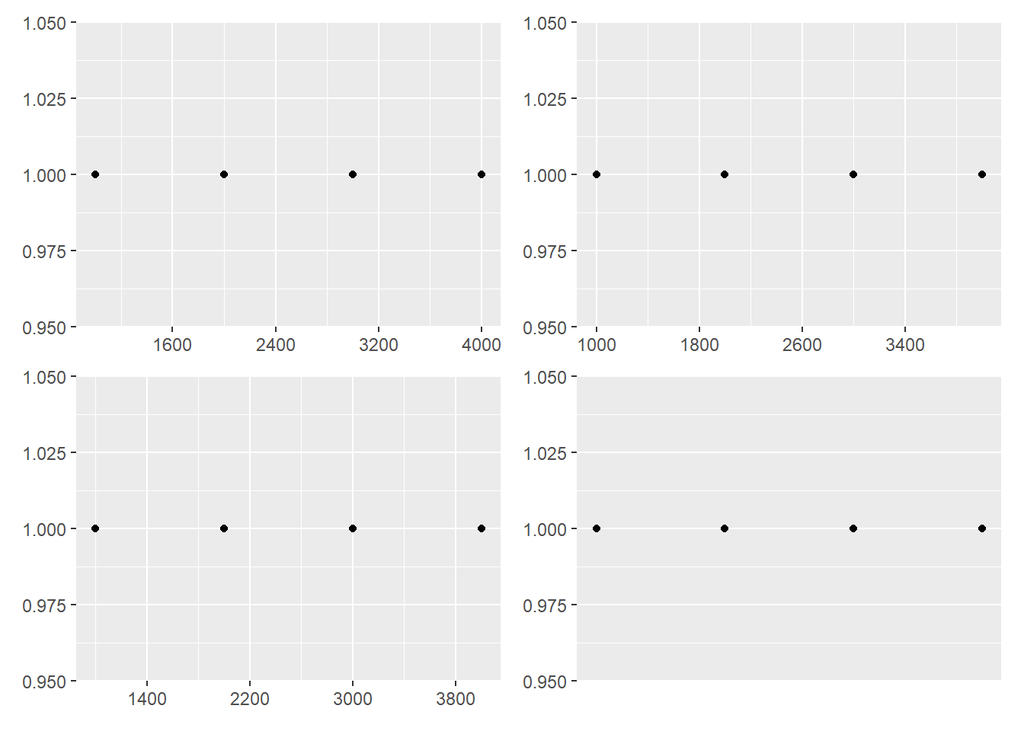

```r
p1 <- axs + scale_x_continuous(breaks = scales::breaks_width(800))
p2 <- axs + scale_x_continuous(breaks = scales::breaks_width(800, offset = 200))
p3 <- axs + scale_x_continuous(breaks = scales::breaks_width(800, offset = -200))
p4 <-  axs + scale_x_continuous(breaks = NULL)

p1 + p2 + p3 + p4
```

## 1.5 labels

A function passed to labels should accept a numeric vector of breaks as input and return a character vector of labels (the same length as the input)

החבילה scales כוללת הרבה סקאלות שימושיות

`scales::label_bytes()` formats numbers as kilobytes, megabytes etc.  
`scales::label_comma()` formats numbers as decimals with commas added.  
`scales::label_dollar()` formats numbers as currency.  
`scales::label_ordinal()` formats numbers in rank order: 1st, 2nd, 3rd etc.  
`scales::label_percent()` formats numbers as percentages.

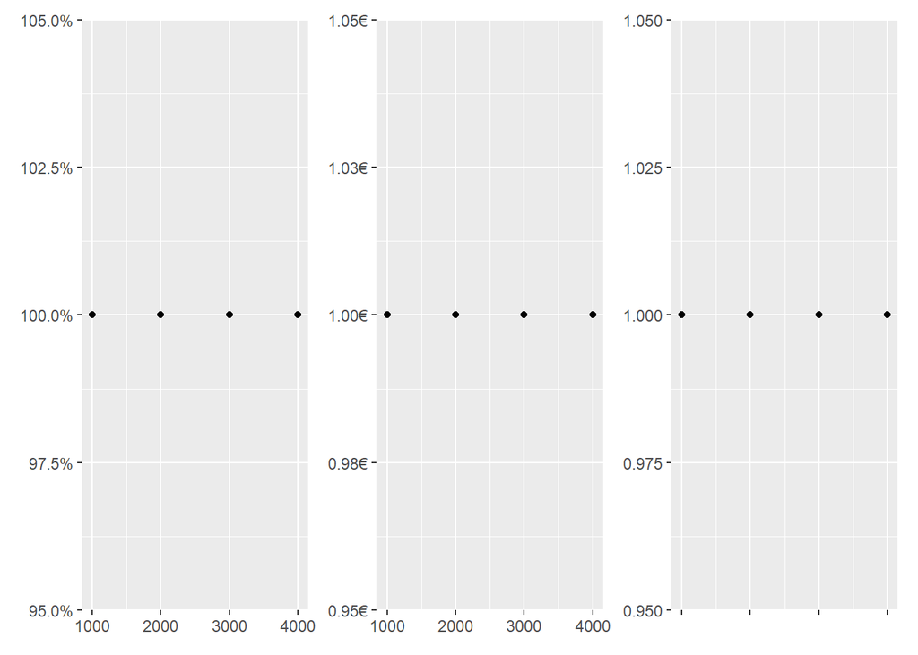

```r
p1 <- axs + scale_y_continuous(labels = scales::label_percent())

p2 <- axs + scale_y_continuous(labels = scales::label_dollar(prefix = "", suffix = "€"))

p3 <- axs + scale_x_continuous(labels = NULL)

p1 + p2 +p3
```

## 1.6 Date-time

If your dates are in a different format you will need to convert them using `as.Date()` , `as.POSIXct()` or `hms::as_hms()`

### 1.6.1 breaks

`scale_x_datetime()`  
The date_breaks argument allows you to position breaks by date units (years, months, weeks, days, hours, minutes, and seconds). For example, `date_breaks = "2 weeks"` will place a major tick mark every two weeks and `date_breaks = 25 years"` will place them every 25 years:

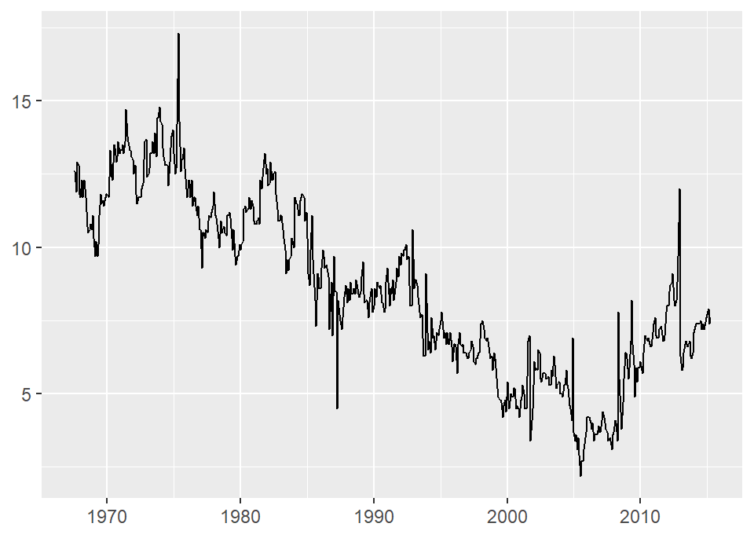

```r
date_base <- ggplot(economics, aes(date, psavert)) +
  geom_line(na.rm = TRUE) +
  labs(x = NULL, y = NULL)

date_base
```

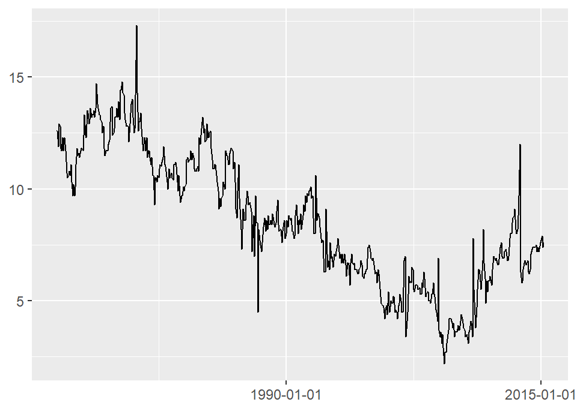

```r
date_base + scale_x_date(date_breaks = "25 years")
```

It may be useful to note that internally `date_breaks = "25 years"` is treated as a shortcut for `breaks = scales::breaks_width("25 years")`. The longer form is typically unnecessary, but it can be useful if—as discussed in Section 1.4 —you wish to specify an offset. Suppose the goal is to plot data that span the 20th century, beginning 1 January 1900, and we wish to set breaks in 25 year intervals. Specifying `date_breaks = "25 years"` produces breaks in the following fashion:

```r
century20 <- as.Date(c("1900-01-01", "1999-12-31"))

breaks <- scales::breaks_width("25 years")

breaks(century20)
```

```
## [1] "1900-01-01" "1925-01-01" "1950-01-01" "1975-01-01" "2000-01-01"
```

Because the range in century 20 starts on 1 January and the breaks increment in whole year values, each of the generated break dates falls on 1 January. We can shift all these breaks so that they fall on 1 February by setting offset = 31 (since there are thirty one days in January).

**minor breaks**

```r
date_base + scale_x_date(
  limits = as.Date(c("2003-01-01", "2003-04-01")),
  date_breaks = "1 month"
)
```

[figure not shown]

```r
date_base + scale_x_date(
  limits = as.Date(c("2003-01-01", "2003-04-01")),
  date_breaks = "1 month",
  date_minor_breaks = "1 week"
)
```

[figure not shown]

### 1.6.2 labels

Like date_breaks, date scales include a date_labels argument. It controls the display of the labels using the same formatting strings as in `strptime()` and `format()`.  
“%d/%m/%Y”

String Meaning %S second (00-59)  
%M minute (00-59)  
%l hour, in 12-hour clock (1-12)  
%I hour, in 12-hour clock (01-12)  
%p am/pm  
%H hour, in 24-hour clock (00-23)  
%a day of week, abbreviated (Mon-Sun)  
%A day of week, full (Monday-Sunday)  
%e day of month (1-31)  
%d day of month (01-31)  
%m month, numeric (01-12)  
%b month, abbreviated (Jan-Dec)  
%B month, full (January-December)  
%y year, without century (00-99)  
%Y year, with century (0000-9999)

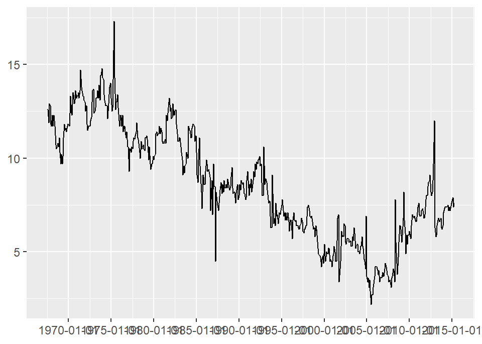

```r
base <- ggplot(economics, aes(date, psavert)) +
  geom_line(na.rm = TRUE) +
  labs(x = NULL, y = NULL)

base + scale_x_date(date_breaks = "5 years")
```

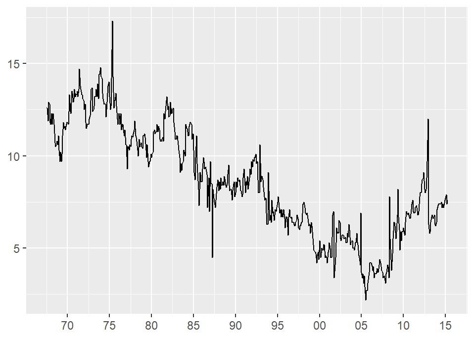

```r
base + scale_x_date(date_breaks = "5 years", date_labels = "%y")
```

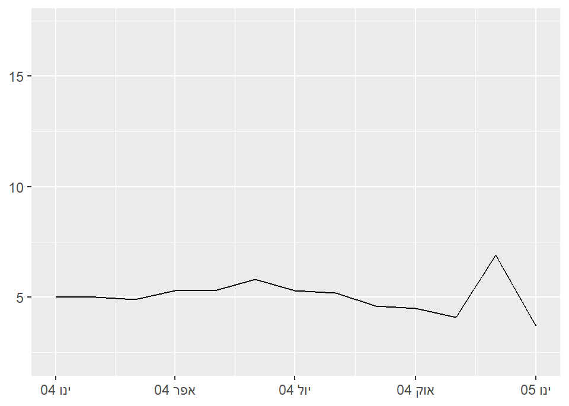

```r
lim <- as.Date(c("2004-01-01", "2005-01-01"))

base + scale_x_date(limits = lim, date_labels = "%b %y")
```

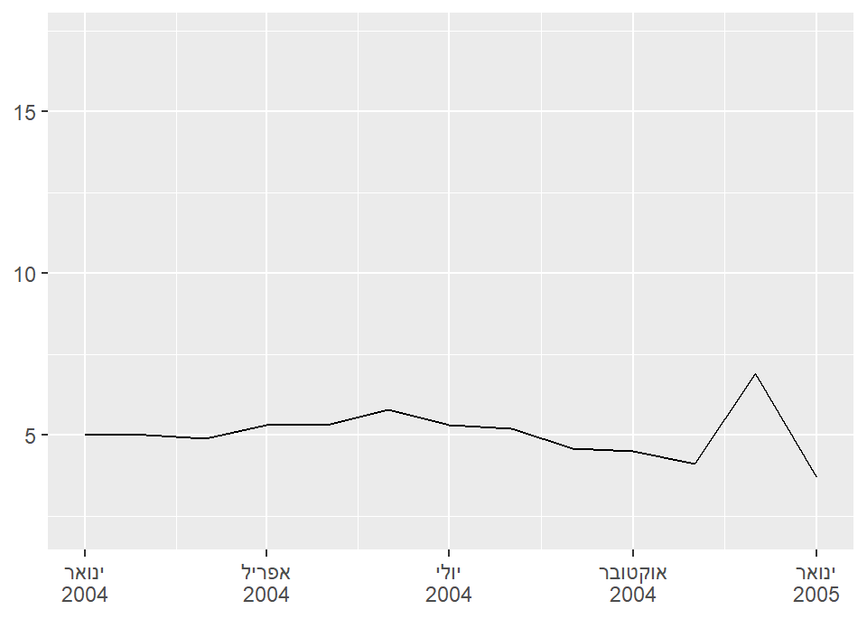

```r
base + scale_x_date(limits = lim, date_labels = "%B\n%Y")
```

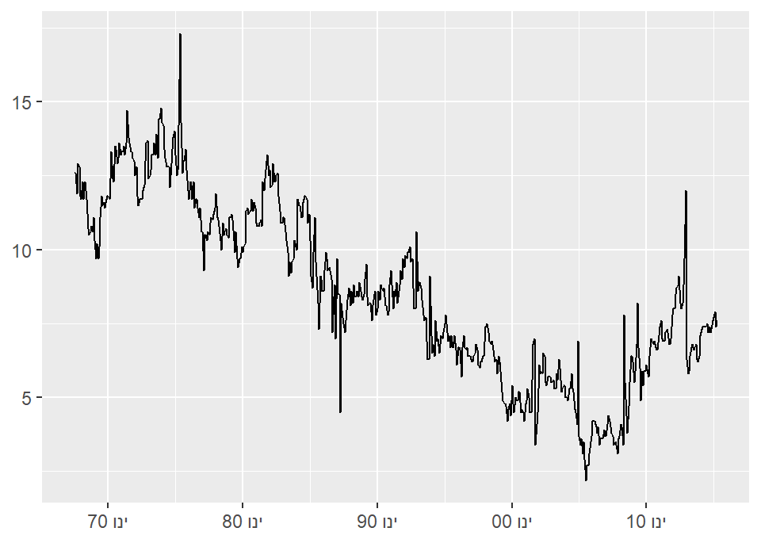

```r
base + scale_x_date(labels = scales::label_date("%b %y"))
```

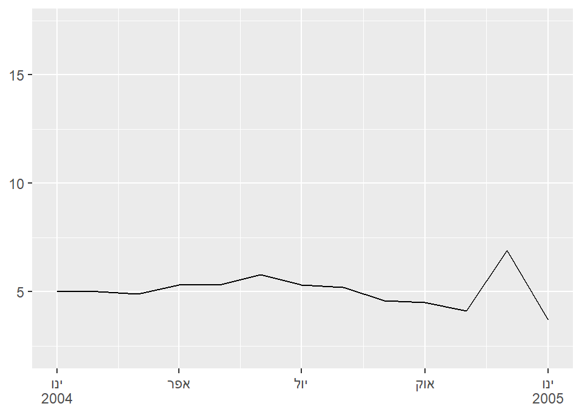

```r
base + scale_x_date(limits = lim, labels = scales::label_date_short())
```

## 1.7 Discrete

When the data are categorical, you also have the option of using a named vector to set the labels associated with particular values. This allows you to change some labels and not others, without altering the ordering or the breaks:

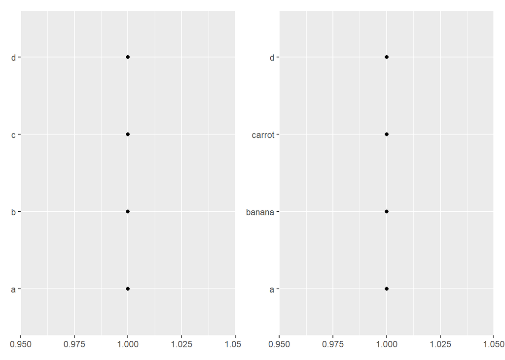

```r
base <- ggplot(toy, aes(const, txt)) +
  geom_point() +
  labs(x = NULL, y = NULL)

base2 <- base + scale_y_discrete(labels = c(c = "carrot", b = "banana"))

base + base2
```

## 1.8 Limits

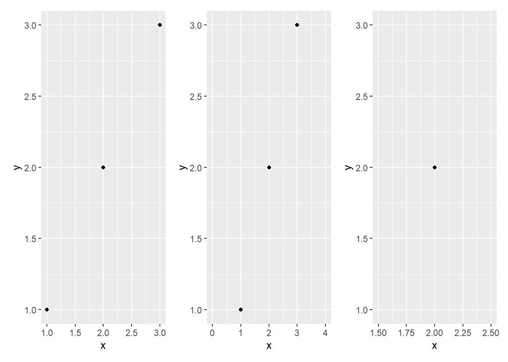

```r
df <- data.frame(x = 1:3, y = 1:3)
base <- ggplot(df, aes(x, y)) + geom_point()

p1 <- base
p2 <- base + scale_x_continuous(limits = c(0, 4))
p3 <- base + scale_x_continuous(limits = c(1.5, 2.5))

p1 + p2 + p3
```

הרחבה של ה limit מועיל כאשר רוצים שני גרפים עם תחום זהה בצירים או ב Legend.

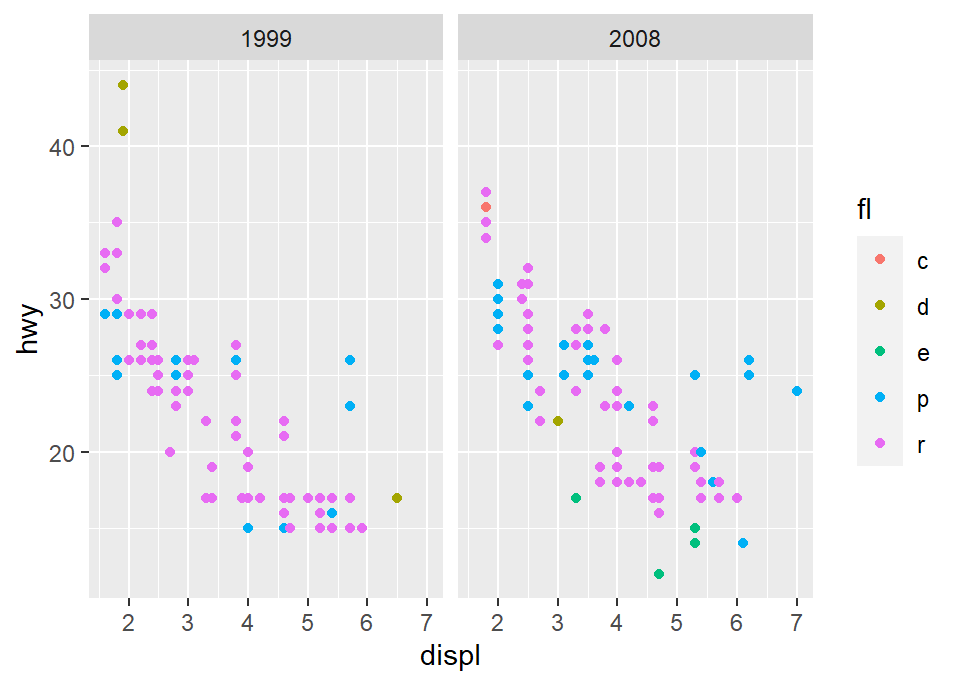

```r
ggplot(mpg, aes(displ, hwy, colour = fl)) +
  geom_point() +
  facet_wrap(vars(year))
```

שני גרפים שונים עם levels שונים במשתנה הקטגורי, מקצים צבעים שונים ל-levels.

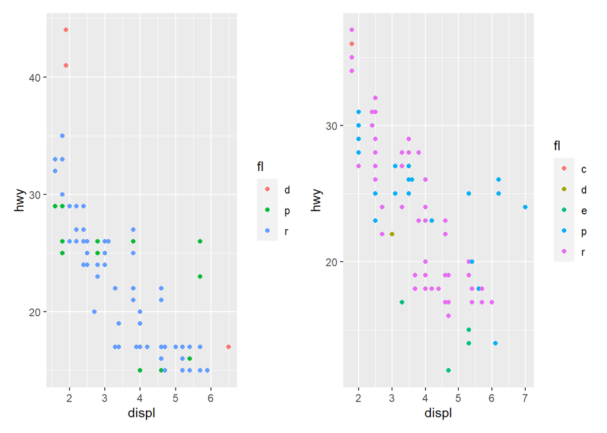

```r
mpg_99 <- mpg %>% filter(year == 1999)
mpg_08 <- mpg %>% filter(year == 2008)

base_99 <- ggplot(mpg_99, aes(displ, hwy, colour = fl)) + geom_point()
base_08 <- ggplot(mpg_08, aes(displ, hwy, colour = fl)) + geom_point()

base_99 + base_08
```

ניתן לפתור זאת באמצעות הקצאת limits

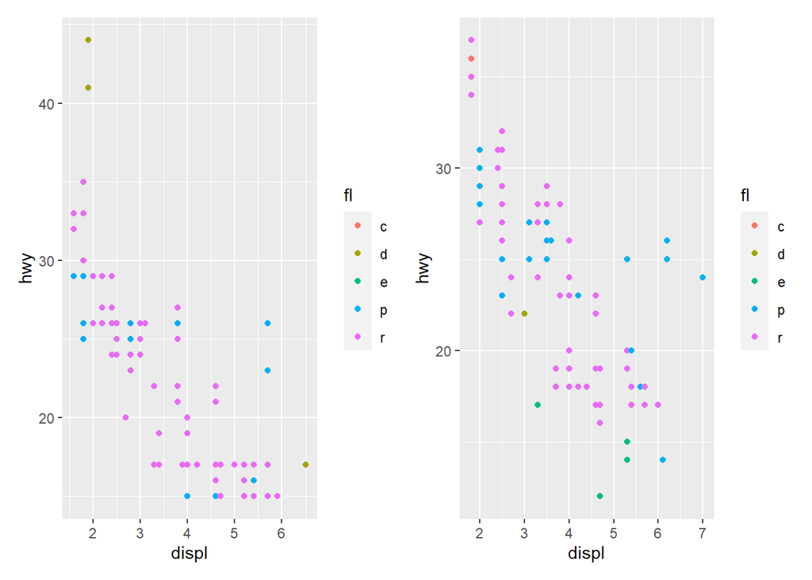

```r
p1 <- base_99 + scale_color_discrete(limits = c("c", "d", "e", "p", "r"))
p2 <- base_08 + scale_color_discrete(limits = c("c", "d", "e", "p", "r"))

p1 + p2
```

נטפל גם בגבולות הצירים

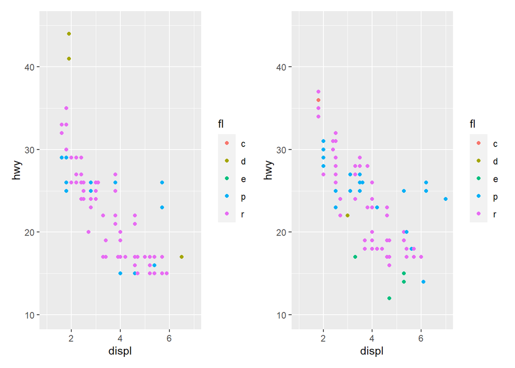

```r
p1 <- base_99 + lims(x = c(1, 7), y = c(10, 45), colour = c("c", "d", "e", "p", "r"))
p2 <- base_08 + lims(x = c(1, 7), y = c(10, 45), colour = c("c", "d", "e", "p", "r"))

p1 + p2
```

אפשרויות נוספות:

`xlim(10, 20)`: a continuous scale from 10 to 20  
`ylim(20, 10)`: a reversed continuous scale from 20 to 10  
`xlim("a", "b", "c")`: a discrete scale  
`xlim(as.Date(c("2008-05-01", "2008-08-01")))`: a date scale from May 1 to August 1 2008

## 1.9 guides

The `guides()` helper works in a similar way to the `labs()` helper function both take the name of different aesthetics (e.g., color, x, fill) as arguments and allow you to specify your own value the `labs` allows to change the names while the `guide` is used to specify the guide of the scale:

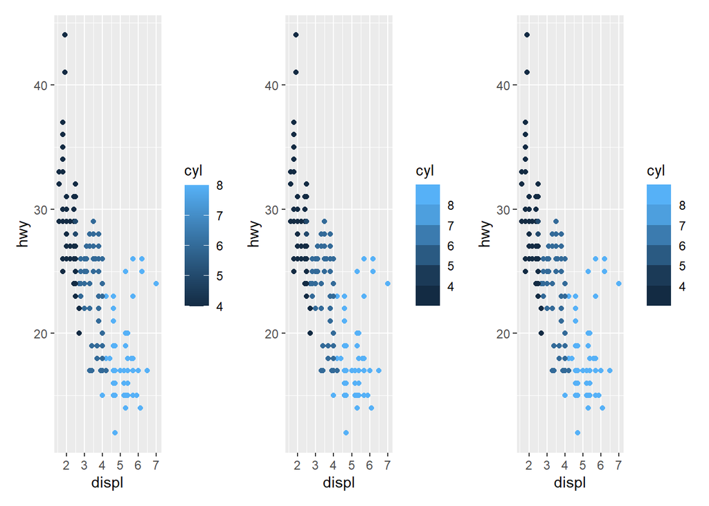

```r
base <- ggplot(mpg, aes(displ, hwy, colour = cyl)) + geom_point()

p1 <- base
p2 <- base + scale_colour_continuous(guide = guide_coloursteps())
p3 <- base + guides(colour = guide_coloursteps())
p1 + p2 + p3
```

Many of the arguments to the guide function are equivalent to theme settings like text colour, size, font etc, but only apply to a single guide.

**guide_axis**

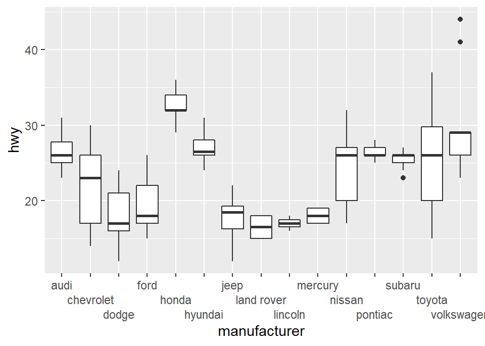

```r
base <- ggplot(mpg, aes(manufacturer, hwy)) + geom_boxplot()

base + guides(x = guide_axis(n.dodge = 3))
```

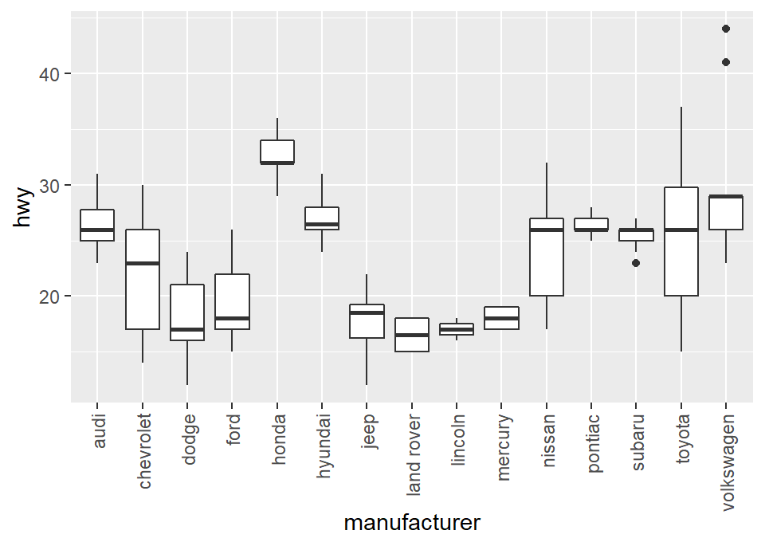

```r
base + guides(x = guide_axis(angle = 90))
```